# Exploratory Analysis on textual data

Poojitha Vishukumar

## Introduction:

Determining useful knowledge from a enormous document collection, effeciently without having to scan through each document in the collection. Information visualization provides a benificial way to conclude documents in ocular form that enables the user to gain knowlledge of data by understanding and intutiveness, Text visualization is an important subfield of information visualization. This project shows an exploratory analysis on textual data, to obtain overall insights of the data.

#### Step 1: Loading Libraries:

```r
library(tm)
library(SnowballC)
```

```r
library(wordcloud)
library(RColorBrewer)
library(dplyr)
library(ggplot2)
library(cluster)
library(philentropy)
library(skmeans)
library(knitr)
library(treemapify)
```

#### Step 2: Loading data : the corpus

```r
data_a <- VCorpus(DirSource("D:/Desktop/NUIG_DA/visualisation/Github_text/corpus", encoding = "UTF-8"), readerControl = list(language = "eng"))
```

#### Step 3: Cleaning the data and Transforming the data

The data corpus is processed by replacing the special characters. Replacing “/”,“@”,and “|” with the help of space.tm_map() function. Later, The data is tranformed using tm_map() function. Unwanted stopwords contained in English language, white spaces, numbers and punctuations are removed. Since the stopwords are common in language, their information value is nearly zero Also, the text in corpus is converted into lowercae and are stemmed.

```r
#Removing unnecessary white space, converting the text to lower case, removing common stopwords.
toSpace <- content_transformer(function (x , pattern ) gsub(pattern, " ", x))
data_a <- tm_map(data_a, toSpace, "/")
data_a <- tm_map(data_a, toSpace, "/.")
data_a <- tm_map(data_a, toSpace, "@")
data_a <- tm_map(data_a, toSpace, "\\|")
data_a <- tm_map(data_a, content_transformer(tolower))
data_a <- tm_map(data_a, removeWords, stopwords("english"))
data_a <- tm_map(data_a, removeNumbers)
data_a <- tm_map(data_a, removeWords, c(letters))
data_a <- tm_map(data_a, stripWhitespace)
data_a <- tm_map(data_a, removePunctuation)
data_a <- tm_map(data_a, stemDocument)
```

#### Step 4: Building document term matrix

```r
data.tdm <- DocumentTermMatrix(data_a, control = list(weighting = function(x) weightTfIdf(x, normalize = TRUE)))
```

#### Step 5: Removal of sparse terms

We create a text document matrix and remove all the sparse terms and sparsity threshold is set to 0.995. It removes the terms which have atleast 0.995 percentage of empty elements.

```r
data.tdm<-removeSparseTerms(data.tdm, 0.995)
data.tdm.matrix <- data.tdm %>% as.matrix()

# remove any zero rows
data.tdm.matrix <- data.tdm.matrix[rowSums(data.tdm.matrix^2) !=0,]
```

#### Step 6:Random sampling: Randomly sampling 25 percentage of documents from corpus

```r
sample_size = nrow(data.tdm.matrix) * 0.25

data.tdm.matrix.sample <- data.tdm.matrix[sample(1:nrow(data.tdm), sample_size, replace=FALSE),]
```

#### Step 7: Hierarchical Clustering

An Hierarchical Clustering groups similar objects and visually gives us a sense of clusters in a dataset. Here, clustering is obtained by creating distance matrix based on cosine similarity.

```r
sim_matrix<-distance(data.tdm.matrix.sample, method = "cosine")
```

```
## Metric: 'cosine'; comparing: 1785 vectors.
```

```r
# Placing document names on columns and rows
colnames(sim_matrix) <- rownames(data.tdm.matrix.sample)
rownames(sim_matrix) <- rownames(data.tdm.matrix.sample)


# Creating a distance measure for hierarchical clustering
max_sim <- max(sim_matrix)

dist_matrix <- as.dist(max_sim-sim_matrix)

# hierarchical clustering
data.tdm.sample.dend <- hclust(dist_matrix, method = "ward.D")


# select only the documents from the random sample taken earlier
data.tdm <- TermDocumentMatrix(data_a)
data.tdm.sample <- data.tdm[, rownames(data.tdm.matrix.sample)]

# convert to r matrix
data.tdm.matrix.sample <- data.tdm.sample %>% as.matrix()
```

#### Step 8: Cutting the dendogram

Inspecting the clustering induced by the dendogram by making a horizontal cut. We then examine the document contents in each cluster.

```r
# number of clusters we wish to examine
k=6


data.tdm.sample.dend.cut <- cutree(data.tdm.sample.dend, k=k)

#number of clusters at the cut
m <- length(unique(data.tdm.sample.dend.cut))

# create a data frame from the cut
data.tdm.sample.dend.cut <- as.data.frame(data.tdm.sample.dend.cut)

#add a meaningful column namane
colnames(data.tdm.sample.dend.cut) = c("cluster")

# add the doc names as an explicit column
data.tdm.sample.dend.cut$docs <- rownames(data.tdm.sample.dend.cut)


data.tdm.sample.dend.cut$docs<-lapply(data.tdm.sample.dend.cut$docs, tm::removeNumbers)

data.tdm.sample.dend.cut$docs <- unlist(data.tdm.sample.dend.cut$docs)
```

#### step 9: creating tree map

Tree map is used to plot the top words in each cluster.Area and color density is used to determine the frequency of the terms in the cluster. In this report I have used area and color to determine the frequency of the term which is also known as double encoding. We can also use a TreeMap to plot the top terms in each cluster.

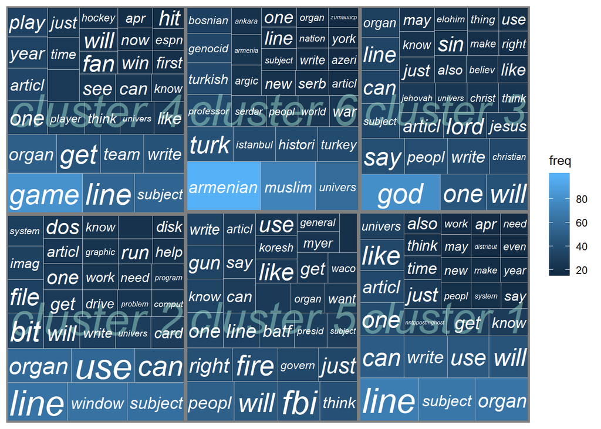

```r
#number of clusters at the cut
m <- length(unique(data.tdm.sample.dend.cut$cluster))

# number of terms per cluster to show
n <-30

#intialise an empty data frame
#fields initiliased with empty vectors
df <- data.frame(word=character(), freq = double(),cluster = integer())

# for each cluster plot an explanatory word cloud
for (i in 1:m) {
  #the documents in  cluster i
  cut_doc_ids <-which(data.tdm.sample.dend.cut$cluster==i)

  #the subset of the matrix with these documents
  data.tdm.sample.mat.cluster<- data.tdm.matrix.sample[, cut_doc_ids]

  # sort the terms by frequency for the documents in this cluster
  val <- sort(rowSums(data.tdm.sample.mat.cluster),decreasing=TRUE)
  dat <- data.frame(word = names(val),freq=val, cluster=i)

  # we might want scale so that high frequencies in large cluster don't predominate
  dat[,2] <- scale(dat[,2],center=FALSE, scale=TRUE)

  # take first n values only
  dat <-dat[1:n,]

  #bind the data for this cluster to the df data frame created earlier
  df<- rbind(df,dat)
}
# the geom_treemap seems to only like vectors of values
df$freq <- as.vector(df$freq)

# simple function to rename the values in the cluster column as "cluster 1, cluster 2, etc"
clust_name<-function(x){
   paste("cluster", x)
}

# apply the function to the 'cluster' column
 df$cluster<- as.character(apply(df["cluster"], MARGIN = 2,FUN =clust_name ))


gg<- ggplot(df, aes(area = freq, fill = freq, subgroup=cluster, label = word)) +
geom_treemap() +
geom_treemap_subgroup_border() +
geom_treemap_subgroup_text(place = "centre", grow = T, alpha = 0.5, colour ="#99d8c9", fontface = "italic", min.size = 10) +
geom_treemap_text(fontface = "italic", colour = "white", place = "centre", grow = TRUE)

gg
```

In the above tree graph, the rectangle with larger area and lighter shade indicates the highest frequency of the term . The words ‘use’, ‘god’,‘armenian’, ‘game’, ‘line’ appear to be frequently occuring with respective to the six clusters.

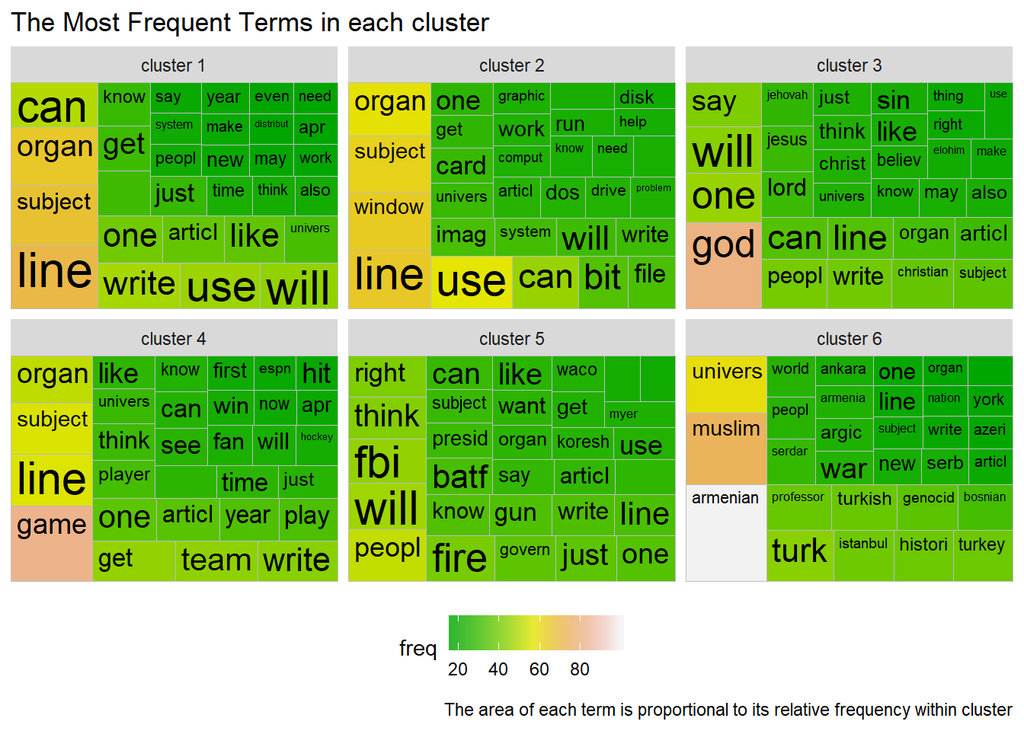

```r
gg<- ggplot(df, aes(area = freq, fill = freq, subgroup=cluster, label = word)) +
geom_treemap() +
  geom_treemap_text(grow = T, reflow = T, colour = "black") +
  facet_wrap( ~ cluster) +

  scale_fill_gradientn(colours = terrain.colors(n, alpha = 0.8)) +
  theme(legend.position = "bottom") +
  labs(title = "The Most Frequent Terms in each cluster ", caption = "The area of each term is proportional to its relative frequency within cluster")

gg
```

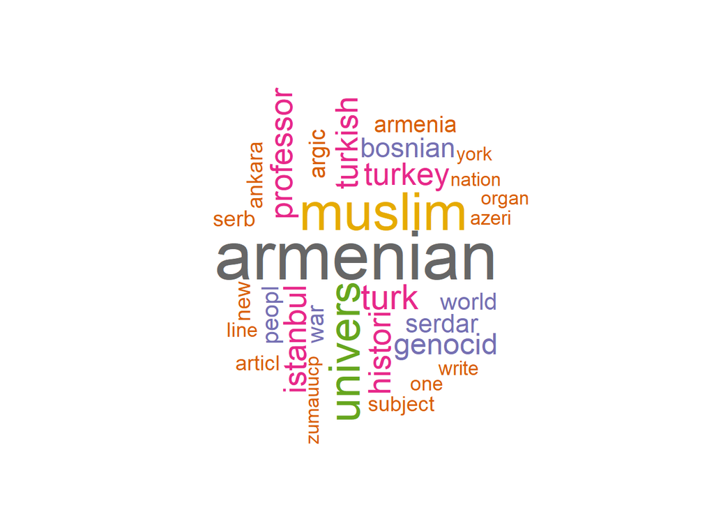

```r
wordcloud(words=dat$word, freq=dat$freq, min.freq = 5,
          max.words = 50,random.order = FALSE, rot.per = 0.35,
          colors = brewer.pal(8,"Dark2"))
```